# EDA of google analytics sample

1. Data Cleaning
2. Numeric Columns Analysis
3. Categorical Column Analysis
4. Feature Engineering
5. Predictive Modeling
6. Business Insights
7. Recommendations

```python
import pandas as pd
import matplotlib.pyplot as plt
import seaborn as sns
import numpy as np
```

```python
df = pd.read_csv("google.csv")
df.info()
```

```
<class 'pandas.core.frame.DataFrame'>
RangeIndex: 1000 entries, 0 to 999
Data columns (total 9 columns):
 #   Column           Non-Null Count  Dtype
---  ------           --------------  -----
 0   source           1000 non-null   object
 1   medium           1000 non-null   object
 2   country          1000 non-null   object
 3   browser          1000 non-null   object
 4   device_category  1000 non-null   object
 5   pageviews        1000 non-null   int64
 6   transactions     34 non-null     float64
 7   date             1000 non-null   int64
 8   hits             1000 non-null   int64
dtypes: float64(1), int64(3), object(5)
memory usage: 70.4+ KB
```

```python
df.head()
```

|  | source | medium | country | browser | device_category | pageviews | transactions | date | hits |
| --- | --- | --- | --- | --- | --- | --- | --- | --- | --- |
| 0 | google | organic | Germany | Firefox | desktop | 17 | NaN | 20160801 | 24 |
| 1 | (direct) | (none) | United States | Internet Explorer | desktop | 18 | NaN | 20160801 | 24 |
| 2 | google | organic | United States | Safari | mobile | 17 | NaN | 20160801 | 27 |
| 3 | (direct) | (none) | United States | Chrome | desktop | 19 | NaN | 20160801 | 27 |
| 4 | google | organic | United States | Chrome | desktop | 17 | NaN | 20160801 | 27 |

## Data Cleaning

### Check Nulls

```python
df.isnull().sum()
```

```
source               0
medium               0
country              0
browser              0
device_category      0
pageviews            0
transactions       966
date                 0
hits                 0
dtype: int64
```

Fill null values with 0

```python
df.head()
```

|  | source | medium | country | browser | device_category | pageviews | transactions | date | hits |
| --- | --- | --- | --- | --- | --- | --- | --- | --- | --- |
| 0 | google | organic | Germany | Firefox | desktop | 17 | NaN | 20160801 | 24 |
| 1 | (direct) | (none) | United States | Internet Explorer | desktop | 18 | NaN | 20160801 | 24 |
| 2 | google | organic | United States | Safari | mobile | 17 | NaN | 20160801 | 27 |
| 3 | (direct) | (none) | United States | Chrome | desktop | 19 | NaN | 20160801 | 27 |
| 4 | google | organic | United States | Chrome | desktop | 17 | NaN | 20160801 | 27 |

All rows have the same date

```python
df['transactions'] = df['transactions'].fillna(0)
df['transactions'].isnull().sum()
```

```
np.int64(0)
```

### Remove Duplicates

```python
df.duplicated().sum()
```

```
np.int64(329)
```

```python
df = df.drop_duplicates()
```

Recheck

```python
df.duplicated().sum()
```

```
np.int64(0)
```

```python
df.duplicated().value_counts()
```

```
False    671
Name: count, dtype: int64
```

## Numeric Columns Analysis

```python
df.describe()
```

|  | pageviews | transactions | date | hits |
| --- | --- | --- | --- | --- |
| count | 671.000000 | 671.000000 | 671.0 | 671.000000 |
| mean | 11.344262 | 0.050671 | 20160801.0 | 15.742176 |
| std | 13.693417 | 0.219488 | 0.0 | 21.955736 |
| min | 1.000000 | 0.000000 | 20160801.0 | 1.000000 |
| 25% | 3.000000 | 0.000000 | 20160801.0 | 4.000000 |
| 50% | 7.000000 | 0.000000 | 20160801.0 | 9.000000 |
| 75% | 14.000000 | 0.000000 | 20160801.0 | 19.000000 |
| max | 133.000000 | 1.000000 | 20160801.0 | 229.000000 |

mean > median , which may indicate right skewness

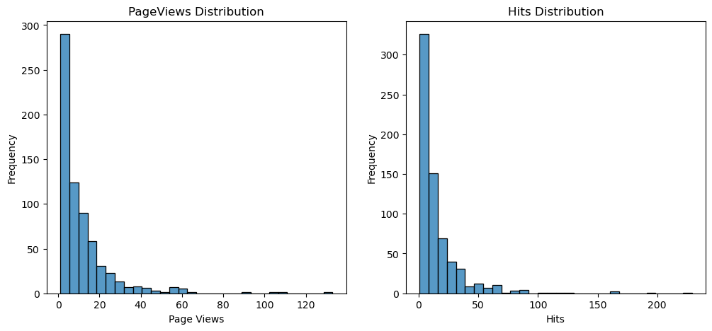

```python
fig, axes = plt.subplots(1,2, figsize=(12,5))

sns.histplot(df['pageviews'], bins=30, ax=axes[0])
axes[0].set_title('PageViews Distribution')
axes[0].set_xlabel('Page Views')
axes[0].set_ylabel('Frequency')

sns.histplot(df['hits'],bins = 30, ax=axes[1])
axes[1].set_title('Hits Distribution')
axes[1].set_xlabel('Hits')
axes[1].set_ylabel('Frequency')

plt.show()
```

### Outliers

```python
num_cols = df.select_dtypes(include='number').columns
def outlier_report(df, col):

    Q1 = df[col].quantile(0.25)
    Q3 = df[col].quantile(0.75)
    IQR = Q3 - Q1

    lower = Q1 - 1.5 * IQR
    upper = Q3 + 1.5 * IQR

    outliers = df[(df[col] < lower) | (df[col] > upper)]

    return {
        "Feature": col,
        "Lower Bound": lower,
        "Upper Bound": upper,
        "Total Outliers": len(outliers),
        "Outlier %": round(len(outliers) / len(df) * 100, 2)
        }
results= []
for col in num_cols:
    results.append(outlier_report(df, col))

outlier_df = pd.DataFrame(results)
outlier_df
```

|  | Feature | Lower Bound | Upper Bound | Total Outliers | Outlier % |
| --- | --- | --- | --- | --- | --- |
| 0 | pageviews | -13.5 | 30.5 | 50 | 7.45 |
| 1 | transactions | 0.0 | 0.0 | 34 | 5.07 |
| 2 | date | 20160801.0 | 20160801.0 | 0 | 0.00 |
| 3 | hits | -18.5 | 41.5 | 47 | 7.00 |

## Categorical Column Analysis

```python
cat_col = ['source', 'medium','country','browser','device_category']
```

### Top 10 for each category

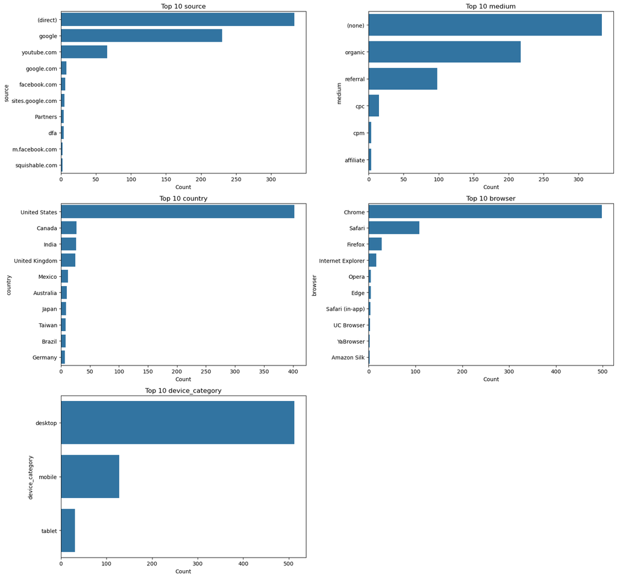

```python
fig,axes = plt.subplots(3,2, figsize=(16,15))
axes = axes.flatten()

for i, col in enumerate(cat_col):
    top10 = df[col].value_counts().head(10)

    sns.barplot(
        x = top10.values ,
        y = top10.index ,
        ax = axes[i]
    )

    axes[i].set_title(f'Top 10 {col}')
    axes[i].set_xlabel('Count')
    axes[i].set_ylabel(col)

fig.delaxes(axes[-1])
plt.tight_layout()
plt.show()
```

### Do mobile and desktop users behave differently?

```python
df.groupby('device_category')[['pageviews', 'hits', 'transactions']].mean()
```

| device_category | pageviews | hits | transactions |
| --- | --- | --- | --- |
| desktop | 12.113281 | 16.859375 | 0.066406 |
| mobile | 9.234375 | 12.570312 | 0.000000 |
| tablet | 7.354839 | 10.387097 | 0.000000 |

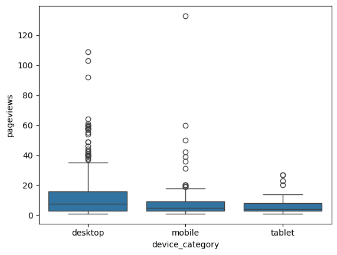

```python
sns.boxplot(x='device_category', y='pageviews', data=df)
```

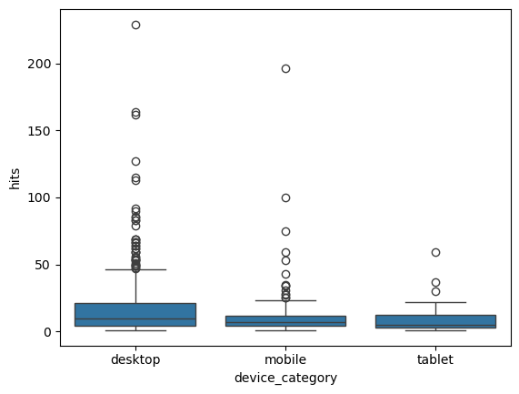

```python
sns.boxplot(x='device_category', y='hits', data=df)
```

- Desktop has higher median values with many outliers, suggesting overall engaged users
- Mobile users have lower median than desktop and has few outliers
- Tablet have lowest median and spread, hence least engagement

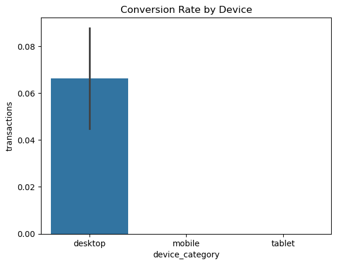

```python
sns.barplot(x='device_category', y='transactions', data=df)
plt.title("Conversion Rate by Device")
plt.show()
```

Desktop devices showed the highest conversion activity, with approximately 6.6% of sessions resulting in transactions. Mobile and tablet devices recorded no transactions in the dataset.

### Which channels bring engaged users?

```python
top5 = (
    df.groupby(['source', 'medium'])[['pageviews', 'hits', 'transactions']]
    .mean()
    .sort_values(by='hits', ascending=False)
    .head(5)
)

top5
```

| source | medium | pageviews | hits | transactions |
| --- | --- | --- | --- | --- |
| basecamp.com | referral | 49.000000 | 69.000000 | 1.000000 |
| dfa | cpm | 32.750000 | 42.000000 | 0.000000 |
| (direct) | (none) | 14.114114 | 19.783784 | 0.072072 |
| gatewaycdi.com | referral | 14.000000 | 18.000000 | 1.000000 |
| google | cpc | 10.466667 | 15.600000 | 0.000000 |

### Country wise analysis

```python
country_df = df[df['country'] != '(not set)']
```

```python
country_analysis = (
    country_df.groupby('country')
    .agg({
        'pageviews': 'mean',
        'hits': 'mean',
        'transactions': ['sum', 'mean']
    })
)

country_analysis.columns = [
    'avg_pageviews',
    'avg_hits',
    'total_transactions',
    'conversion_rate'
]

country_analysis['conversion_rate'] *= 100

country_analysis.sort_values(
    by='conversion_rate',
    ascending=False
).head(10)
```

| country | avg_pageviews | avg_hits | total_transactions | conversion_rate |
| --- | --- | --- | --- | --- |
| Kenya | 18.500000 | 26.000000 | 1.0 | 25.000000 |
| Mexico | 10.250000 | 14.250000 | 1.0 | 8.333333 |
| United States | 14.072139 | 19.825871 | 32.0 | 7.960199 |
| Albania | 2.000000 | 2.000000 | 0.0 | 0.000000 |
| Poland | 5.000000 | 7.333333 | 0.0 | 0.000000 |
| Saudi Arabia | 9.500000 | 11.500000 | 0.0 | 0.000000 |
| Russia | 7.400000 | 8.600000 | 0.0 | 0.000000 |
| Romania | 2.000000 | 2.000000 | 0.0 | 0.000000 |
| Puerto Rico | 2.000000 | 3.000000 | 0.0 | 0.000000 |
| Portugal | 4.000000 | 5.500000 | 0.0 | 0.000000 |

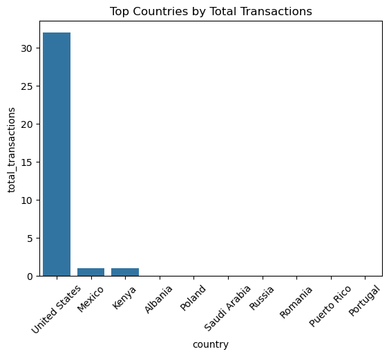

```python
top_transactions = (
    country_analysis
    .sort_values(by='total_transactions', ascending=False)
    .head(10)
)

sns.barplot(
    x=top_transactions.index,
    y=top_transactions['total_transactions']
)

plt.xticks(rotation=45)
plt.title("Top Countries by Total Transactions")
plt.show()
```

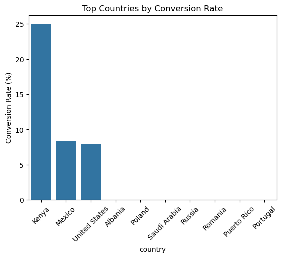

```python
top_conversion = (
    country_analysis
    .sort_values(by='conversion_rate', ascending=False)
    .head(10)
)

sns.barplot(
    x=top_conversion.index,
    y=top_conversion['conversion_rate']
)

plt.xticks(rotation=45)
plt.ylabel("Conversion Rate (%)")
plt.title("Top Countries by Conversion Rate")
plt.show()
```

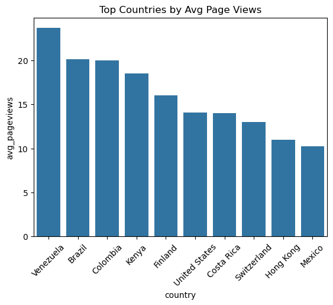

```python
top_pageviews = (
    country_analysis
    .sort_values(by='avg_pageviews', ascending=False)
    .head(10)
)

sns.barplot(
    x=top_pageviews.index,
    y=top_pageviews['avg_pageviews']
)

plt.xticks(rotation=45)
plt.title("Top Countries by Avg Page Views")
plt.show()
```

### Browser Analysis

```python
df.groupby('browser')[['pageviews', 'hits']].mean()
```

| browser | pageviews | hits |
| --- | --- | --- |
| Amazon Silk | 5.000000 | 5.500000 |
| Chrome | 12.564257 | 17.534137 |
| Edge | 11.800000 | 13.000000 |
| Firefox | 8.607143 | 11.071429 |
| Internet Explorer | 6.750000 | 8.062500 |
| Opera | 2.400000 | 4.000000 |
| Safari | 8.037037 | 11.314815 |
| Safari (in-app) | 7.000000 | 10.750000 |
| UC Browser | 3.666667 | 4.000000 |
| YaBrowser | 9.000000 | 9.500000 |

Chrome brings the highest engagement, followed by Edge

### Correlation Analysis

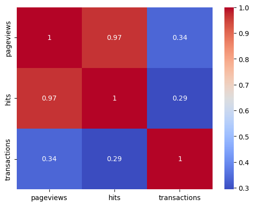

```python
corr = df[['pageviews', 'hits', 'transactions']].corr()

sns.heatmap(corr, annot=True, cmap='coolwarm')
plt.show()
```

Page views and hits are strongly correlated

### Transaction Analysis

```python
df.groupby('transactions')[['pageviews', 'hits']].mean()
```

| transactions | pageviews | hits |
| --- | --- | --- |
| 0.0 | 10.284144 | 14.252747 |
| 1.0 | 31.205882 | 43.647059 |

Users who completed transactions showed higher engagement levels, indicating strong association between interaction and conversion/transaction likeliehood

#### Conversion rate by source

```python
conversion_rate = df.groupby('source')['transactions'].mean() * 100
conversion_rate
```

```
source
(direct)                 7.207207
Partners                 0.000000
basecamp.com           100.000000
dfa                      0.000000
facebook.com             0.000000
gatewaycdi.com         100.000000
google                   3.043478
google.com               0.000000
google.com.au            0.000000
google.com.mx            0.000000
gophergala.com           0.000000
m.facebook.com           0.000000
mail.google.com          0.000000
optimize.google.com      0.000000
quora.com                0.000000
sites.google.com         0.000000
squishable.com           0.000000
startpage.com            0.000000
yahoo                    0.000000
youtube.com              1.515152
Name: transactions, dtype: float64
```

## Feature Engineering

### 1. Engagement Level

```python
df['engagement_level'] = pd.qcut(
    df['pageviews'],
    q=3,
    labels=['Low', 'Medium', 'High'])

# qcut ensure equal number of users for each segment
```

```python
cats, bins = pd.qcut(df['pageviews'], q=3, retbins=True)
print(bins)
```

```
[  1.   4.  11. 133.]
```

### Do highly engaged users convert more?

```python
df.groupby('engagement_level')['transactions'].mean()
```

```
engagement_level
Low       0.000000
Medium    0.014286
High      0.144860
Name: transactions, dtype: float64
```

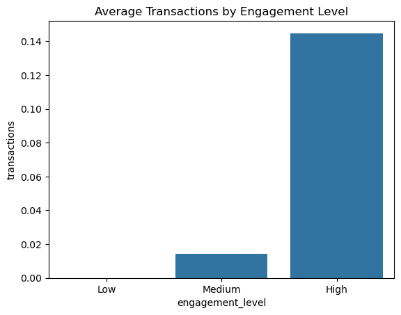

```python
engagement_conversion = (
    df.groupby('engagement_level')['transactions']
    .mean()
    .reset_index()
)

sns.barplot(
    x='engagement_level',
    y='transactions',
    data=engagement_conversion
)

plt.title("Average Transactions by Engagement Level")
plt.show()
```

```python
df.groupby('engagement_level')['transactions'].mean() * 100
```

```
engagement_level
Low        0.000000
Medium     1.428571
High      14.485981
Name: transactions, dtype: float64
```

### 2. Hits per page

```python
df['hits_per_page'] = df['hits']/df['pageviews']
```

```python
threshold = df['hits_per_page'].median()

df['interaction_type'] = df['hits_per_page'].apply(
    lambda x: 'High Interaction' if x > threshold else 'Low Interaction'
)
```

```python
df.groupby('interaction_type')['transactions'].mean()
```

```
interaction_type
High Interaction    0.066869
Low Interaction     0.035088
Name: transactions, dtype: float64
```

## Predictive Modeling

Predict if a user will convert or not

```python
x = df[['pageviews', 'hits']]
y = df['transactions']
```

```python
from sklearn.model_selection import train_test_split

x_train, x_test, y_train, y_test = train_test_split(
    x, y, test_size=0.2, random_state=42
)
```

```python
from sklearn.linear_model import LogisticRegression

model1 = LogisticRegression(max_iter=1000, class_weight='balanced')
model1.fit(x_train, y_train)
```

```
LogisticRegression(class_weight='balanced', max_iter=1000)
```

```python
y_pred1 = model1.predict(x_test)
```

```python
from sklearn.metrics import accuracy_score, classification_report

print("MODEL 1 ACCURACY:", accuracy_score(y_test, y_pred1))
print(classification_report(y_test, y_pred1))
```

```
MODEL 1 ACCURACY: 0.8148148148148148
              precision    recall  f1-score   support

         0.0       0.99      0.81      0.89       127
         1.0       0.23      0.88      0.36         8

    accuracy                           0.81       135
   macro avg       0.61      0.84      0.63       135
weighted avg       0.95      0.81      0.86       135
```

A Logistic Regression model was developed to explore whether user engagement metrics could predict session conversions.

Due to the highly imbalanced nature of the dataset and limited positive transaction samples, the model struggled to reliably predict conversion events.  
Additional behavioral, temporal, or customer-level features may be required to improve predictive performance.

## Business Insights

#### Device Category

- Desktop users show the highest engagement compared to mobile and tablet users.
- Most transactions are generated from desktop users, while mobile and tablet contribute very little to no conversions.

#### Source and Medium

- Basecamp.com (referral traffic) generates the highest user engagement.
- Basecamp.com and gatewaycdi.com show very high conversion rates; however, this may be influenced by low sample size.
- Google brings high traffic volume but has a relatively low conversion rate (~3%), indicating lower efficiency despite high reach.

#### Country

- United States contributes the highest number of total transactions.
- Kenya shows the highest conversion rate, but this may be affected by a small number of observations.

#### Browser

- Chrome users have the highest engagement, followed by Edge.
- Opera shows the lowest engagement among all browsers.

#### Pageviews and Hits

- Pageviews and hits are highly correlated (~0.97), indicating both metrics capture similar user behavior.

#### Engagement and Transactions

- Higher engagement levels are strongly associated with a higher likelihood of transactions.

## Recommendations

- Improve the mobile experience, since most conversions come from desktop users. A smoother mobile layout, faster loading speed, and simpler checkout process could help increase mobile sales.
- Invest more in referral sources like Basecamp.com, which bring highly engaged users and strong conversion performance. At the same time, validate results from smaller traffic sources before making major decisions.
- Optimize Google marketing campaigns. Although Google drives large traffic volumes, the conversion rate is relatively low, suggesting that targeting and landing pages can be improved.
- Continue focusing on the United States market because it generates the highest number of transactions. Countries with high conversion rates but smaller traffic volumes can be explored further for growth opportunities.
- Ensure the website performs consistently across browsers, especially Chrome and Edge, while checking for possible usability or compatibility issues on Opera.
- Since pageviews and hits measure very similar user behavior, one of these variables can be removed in future modeling to simplify analysis.
- Focus on increasing user engagement through better recommendations, easier navigation, and improved product discovery, as higher engagement is strongly linked with higher transaction rates.